# Practical Machine Learning Assignment Writeup

Lars Skjaerven

1/29/2018

## Introduction

The goal of the project is to predict the exercise manner (or quality) of six participants based on a number of predictor variables. The outcome is stored in the `classe` variable of the training set. I will explore several classifiers to solve this problem, notably **random forest**, **gradient boosting**, **linear discriminant analysis**, **support vector machine**, and **k-nearest neighbour**. Finally I will apply the best model to predict the 20 cases in the test set. I will further calculate the importance of the predictors (variables) based on our most successful model, and use the result of the importance to explore the underlying data.

## Data import

Import required libraries, download data files, and use `read_csv()` to parse the csv files:

```r
# Load required packages
library(caret)
library(readr)
library(corrplot)
```

```r
# Download data files
download.file("https://d396qusza40orc.cloudfront.net/predmachlearn/pml-training.csv", "pml-train.csv")
download.file("https://d396qusza40orc.cloudfront.net/predmachlearn/pml-testing.csv", "pml-test.csv")

# Read data
train.orig <- read_csv("pml-train.csv")
train.orig$classe <- as.factor(train.orig$classe)
test.orig <- read_csv("pml-test.csv")
```

The training data consists of **19622** rows with **160** columns. There are **20** rows in the test set. The `classe` variable contains the following grades:

```r
# Table of outcome 'classe'
table(train.orig$classe)
```

```
##
##    A    B    C    D    E
## 5580 3797 3422 3216 3607
```

## Data cleanup

The training dataset contains 7 columns that does not provide informative data for predicting the training outcome: **X1, user_name, raw_timestamp_part_1, raw_timestamp_part_2, cvtd_timestamp, new_window, num_window**.

```r
# Remove first 7 columns
train <- train.orig
train <- train[, -c(1:7)]
```

```r
# Explore missing data rows/cols
missing <- apply(train, 2, function(x) sum(is.na(x)))
table(missing)
```

```
## missing
##     0     1 19216 19217 19218 19220 19221 19293 19294
##    50     3    91     1     1     1     4     1     1
```

```r
# Chop off columns with lots of missing data
excl.inds <- missing < 5
train <- train[, excl.inds]
```

There seems to be one row with 3 missing values. Delete row:

```r
# Where are the other misisng data points?
excl.rows <- which(apply(train, 1, function(x) sum(is.na(x))) > 0)
train <- train[-excl.rows, ]
```

That leaves us with **52** predictor variables in the training dataset.

## Data partitioning

For building the model we need a test set with known `classe` outcome variable. Let’s split the training set into a test and training set using the `createDataPartition()` function of the caret package:

```r
# Split data set
inTrain <- createDataPartition(y=train$classe, p=0.7, list=FALSE)
mytest <- train[-inTrain,]
train <- train[inTrain,]
```

This gives **5884** rows in the test set and **13737** rows in the final training set.

## Model building

Set up a common `trainControl` object to use in all models we explore. We will use a **5-fold cross-validation** in the following models.

```r
# set up a trainControl object with 5-fold cross-validation
trc <- trainControl(method="cv", number=5)
```

### Random forest

We start with exploring the **random forest** algorithm (provided with the **ranger** package). Use the train control object defined above with 5-fold cross-validation. Specify `importance = 'impurity'` to obtain the importance of the variables in the fitting. Use `predict` on the test set, and call `confusionMatrix()` to evaluate the model.

```r
# Random forest
mod_rf <- train(classe ~ .,
                method="ranger", data=train,
                trControl=trc,
                importance = 'impurity')

# Predict on test data
pred_rf <- predict(mod_rf, mytest)

# Cross-table
table(pred_rf, mytest$classe)
```

```
##
## pred_rf    A    B    C    D    E
##       A 1672    4    0    0    0
##       B    1 1135    6    0    0
##       C    0    0 1020    6    3
##       D    0    0    0  958    1
##       E    0    0    0    0 1078
```

```r
# Calcualte confusion matrix
cm_rf <- confusionMatrix(pred_rf, mytest$classe)
```

This model provides a fantastic accuracy of **0.996**.

Use `varImp()` of the **caret** package to explore what’s driving the prediction:

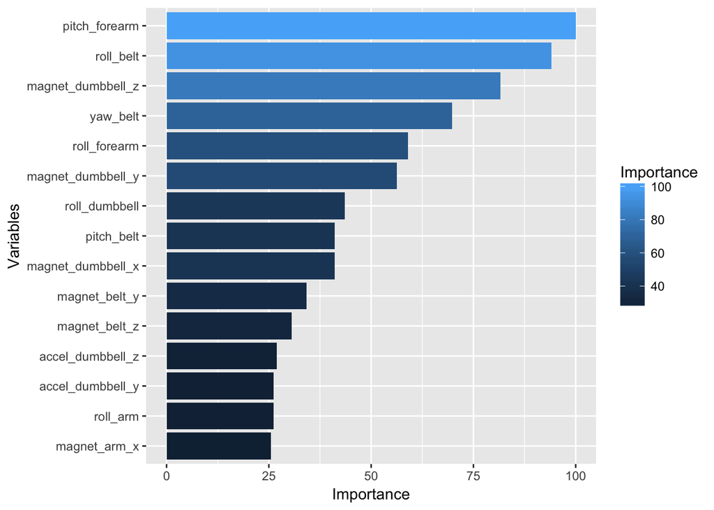

```r
# Find varialbe importance
rfImp <- varImp(mod_rf)

# Make a barplot
df <- data.frame(Importance = unname(rfImp$importance), Vars=rownames(rfImp$importance))
df = df[order(df$Importance, decreasing = TRUE), ][1:15, ]

# Plot importance
ggplot(df, aes(x = reorder(Vars, Importance),
    y = Importance, fill = Importance)) +
  geom_bar(stat='identity') +
  labs(x = 'Variables') +
  coord_flip()
```

Looks like a few key variables are driving most of the model with **pitch_forearm** and **roll_belt** being the most important. How does the underlying data look like? The following box plots illustrate some of they key variables. E.g. `pitch_forearm` close to 0 seems important for obtaining an **A**.

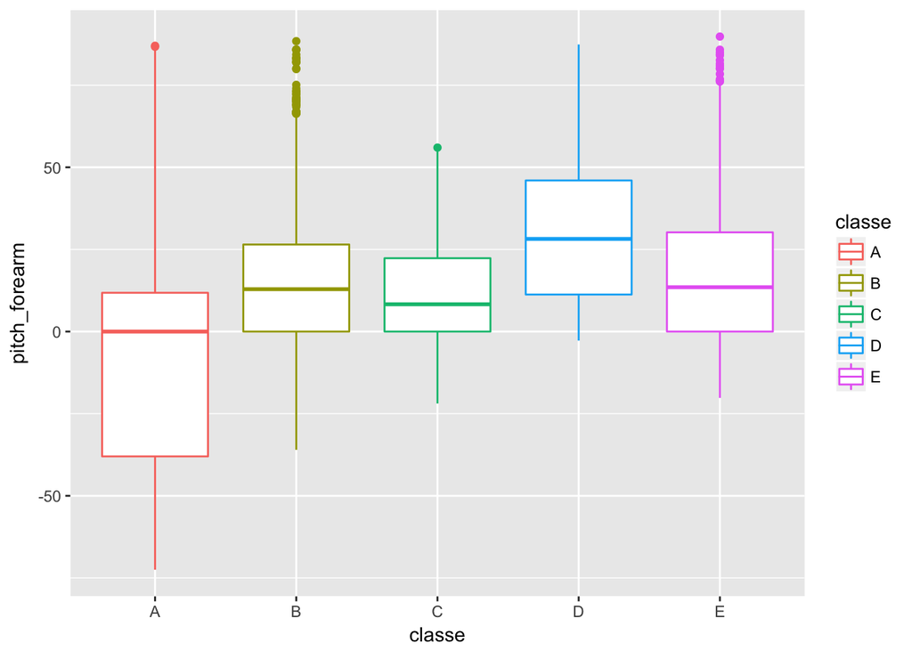

```r
# Plot important variables
ggplot(train, aes(classe, pitch_forearm)) +
  geom_boxplot(aes(col=classe))
```

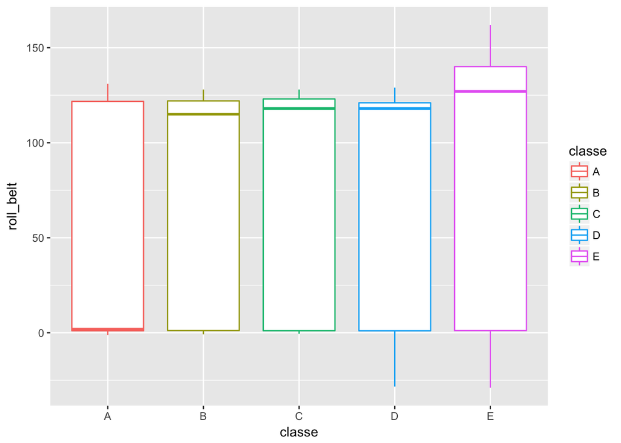

```r
ggplot(train, aes(classe, roll_belt)) +
  geom_boxplot(aes(col=classe))
```

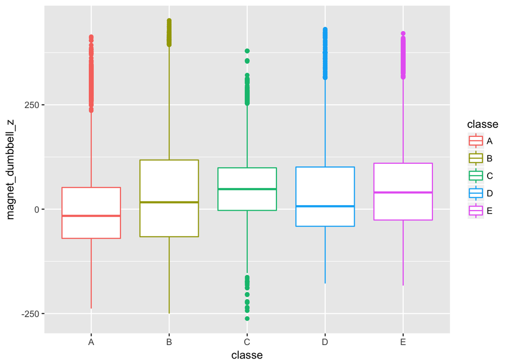

```r
ggplot(train, aes(classe, magnet_dumbbell_z)) +
  geom_boxplot(aes(col=classe))
```

## Final prediction on the test set

Based on the random forest model we predict the 20 data points of the test set:

```r
predict(mod_rf, test.orig)
```

```
##  [1] B A B A A E D B A A B C B A E E A B B B
## Levels: A B C D E
```

## Exploring other models

Although the random forest model provides an accuracy of **0.996**, we will check how other popular algorithms performs under default settings:

### Gradient Boosting

```r
# Boosting
mod_gbm <- train(classe ~ .,
                 method="gbm", data=train,
                 trControl=trc, verbose=FALSE)

pred_gbm <- predict(mod_gbm, mytest)
table(pred_gbm, mytest$classe)
```

```
##
## pred_gbm    A    B    C    D    E
##        A 1648   39    0    1    1
##        B   20 1063   31    1   14
##        C    5   36  989   31   10
##        D    0    1    5  924   13
##        E    0    0    1    7 1044
```

```r
cm_gbm <- confusionMatrix(pred_gbm, mytest$classe)
cm_gbm$overall["Accuracy"]
```

```
##  Accuracy
## 0.9632903
```

### Linear Discriminant Analysis

```r
# Linear Discriminant Analysis
mod_lda <- train(classe ~ .,
                 method="lda", data=train,
                 trControl=trc)

pred_lda <- predict(mod_lda, mytest)
table(pred_lda, mytest$classe)
```

```
##
## pred_lda    A    B    C    D    E
##        A 1365  188  102   56   34
##        B   40  718  108   37  180
##        C  134  138  667  124  104
##        D  130   41  129  714  102
##        E    4   54   20   33  662
```

```r
cm_lda <- confusionMatrix(pred_lda, mytest$classe)
cm_lda$overall["Accuracy"]
```

```
##  Accuracy
## 0.7012237
```

### k-nearest neighbors

```r
mod_knn <- train(classe ~ .,
                method = "knn",
                data = train,
                trControl = trc)
pred_knn <- predict(mod_knn, mytest)
table(pred_knn, mytest$classe)
```

```
##
## pred_knn    A    B    C    D    E
##        A 1612   66    9    9   16
##        B   15  983   49   13   38
##        C   12   40  922   63   22
##        D   29   26   30  868   44
##        E    5   24   16   11  962
```

```r
cm_knn <- confusionMatrix(pred_knn, mytest$classe)
cm_knn$overall["Accuracy"]
```

```
##  Accuracy
## 0.9087356
```

### SVM

```r
mod_svm <- train(classe ~ .,
                method = "svmLinear",
                data = train,
                trControl = trc)
pred_svm <- predict(mod_svm, mytest)
table(pred_svm, mytest$classe)
```

```
##
## pred_svm    A    B    C    D    E
##        A 1546  156   72   58   50
##        B   25  807   87   41  147
##        C   49   81  819  104   64
##        D   46   17   28  711   67
##        E    7   78   20   50  754
```

```r
cm_svm <- confusionMatrix(pred_svm, mytest$classe)
cm_svm$overall["Accuracy"]
```

```
##  Accuracy
## 0.7880693
```

## Preprocessing data

```r
# Boosting
mod_gbm_pp <- train(classe ~ .,
                 method="gbm", data=train,
                 preProcess=c("center", "scale"),
                 trControl=trc, verbose=FALSE)

pred_gbm_pp <- predict(mod_gbm_pp, mytest)
table(pred_gbm_pp, mytest$classe)
```

```
##
## pred_gbm_pp    A    B    C    D    E
##           A 1650   44    0    1    1
##           B   19 1060   37    2   12
##           C    4   30  980   31    9
##           D    0    3    8  923   13
##           E    0    2    1    7 1047
```

```r
cm_gbm_pp <- confusionMatrix(pred_gbm_pp, mytest$classe)
cm_gbm_pp$overall["Accuracy"]
```

```
##  Accuracy
## 0.9619307
```

## Conclusion

Random forest seems to be an excellent model for predicting exercise manner with an accuracy of **0.996**. k-NN gives an accuracy of **0.909** while gradient boosting gives an accuracy of **0.963**.